# BCB420 Assignment 1

Kevin Zhu

## Objective of Assignment 1

The objective of this assignment is to produce a clean, normalized dataset that will be used for the following tasks in this course.

## Dataset Overview

γ-Secretase is a protease known to cleave the CTFs of amyloid-beta precursor protein (APP) at its gamma site. It is also known to cleave other substrates, and has been associated pathways governing cell differentiation. However, we still do not have a full understanding of what γ-Secretase does to non-proliferating cells (such as neurons).

Dysfunction of lipid metabolism neurons has been linked with Alzheimer’s Disease. In mouse embryonic fibroblasts (MEFs), γ-secretase inhibition lowered cellular cholesterol ester levels and reduced endocytosis of the low-density lipoprotein receptor (LDLR). However, No studies were carried out in human neurons, whose cholesterol metabolism is uniquely different from that of glia or peripheral cells.

The authors conducted RNA-seq experiments six biological replicates of induced human neuron cells. There were three treatment protocols: Control, DAPT, and LY411575. Specifically, DAPT and LY411575 treatments pharmaceutically induced chronic inhibition of γ-secretase. The associated GEO ID for this dataset is **GSE206102**.

## Installing dependencies and dowloading the packages

These dependencies has are already included with the command in the docker file

```r
if (!requireNamespace("BiocManager", quietly = TRUE)){
  install.packages("BiocManager")}

if (!requireNamespace("GEOmetadb", quietly = TRUE)){
  BiocManager::install("GEOmetadb")}

if (!requireNamespace("GEOmetadb", quietly = TRUE)){
  install.packages("knitr")}

if (!requireNamespace("edgeR", quietly = TRUE)){
  BiocManager::install("edgeR")}

if (!requireNamespace("biomaRt", quietly = TRUE)){
  BiocManager::install("biomaRt")}

if (!requireNamespace("DBI", quietly = TRUE)){
  install.packages("DBI")}

if (!requireNamespace("GEOquery", quietly = TRUE)){
  BiocManager::install("GEOquery")}

library(GEOquery)
library(knitr)
library(edgeR)
library(biomaRt)
library(dplyr)
library(purrr)
```

## Step 1: Loading the Expression Dataset

This step retrieves the gene expression data from the GEO, using the accession number **GSE206102**.

### Introduction of Dataset

```r
dataset_geo_id <- 'GSE206102'

# downloading GEO dataset
gse <- getGEO(dataset_geo_id ,GSEMatrix = FALSE)

# Information about Platform
current_gpl <- names(GPLList(gse))[1]
current_gpl_info <- Meta(getGEO(current_gpl))

list_of_samples <- gse@gsms
```

**GEO ID:** GSE206102

**Dataset Name:** Neuronal γ-secretase regulates lipid metabolism, linking cholesterol to synaptic dysfunction in Alzheimer’s disease

**Platform Title:** Illumina NovaSeq 6000 (Homo sapiens; Mus musculus)

**Technology:** high-throughput sequencing

**Submission Date:** Sep 04 2018

**Last Update Date:** Sep 04 2018

**Organism:** Homo sapiens, Mus musculus

```r
# getting the sample descriptions
samples_type <- do.call(rbind, lapply(list_of_samples,
                                      FUN=function(x){
                                        c(x@header$title,
                                          x@header$characteristics_ch1)
                                        }
                                      )
                        )

colnames(samples_type) <- c("title",
                            "tissue",
                            "cell line",
                            "cell type",
                            "genotype",
                            "treatment")

samples_type[,'tissue'] <- gsub(samples_type[,'tissue'],
                                pattern = "tissue: ", replacement = "")
samples_type[,'cell line'] <- gsub(samples_type[,'cell line'],
                                   pattern = "cell line: ", replacement = "")
samples_type[,'cell type'] <- gsub(samples_type[,'cell type'],
                                   pattern = "cell type: ", replacement = "")
samples_type[,'genotype'] <- gsub(samples_type[,'genotype'],
                                   pattern = "genotype: ", replacement = "")
samples_type[,'treatment'] <- gsub(samples_type[,'treatment'],
                                   pattern = "treatment: ", replacement = "")

kable(samples_type[1:6,], format = "html")
```

|  | title | tissue | cell line | cell type | genotype | treatment |
| --- | --- | --- | --- | --- | --- | --- |
| GSM6241696 | Replicate1_CtrlV | Co-cultures of human induced neurons grown on mouse glia feeder layer | Human Induced Neurons from H1 ESC (WA01) | Human induced neurons, day 40 / mouse primary glia | Wild-type human induced neurons / CD1 mouse glia | Vehicle (0.5% DMSO), day in vitro 10-40 |
| GSM6241697 | Replicate1_DAPT | Co-cultures of human induced neurons grown on mouse glia feeder layer | Human Induced Neurons from H1 ESC (WA01) | Human induced neurons, day 40 / mouse primary glia | Wild-type human induced neurons / CD1 mouse glia | DAPT (40 uM), day in vitro 10-40 |
| GSM6241698 | Replicate1_LY411575 | Co-cultures of human induced neurons grown on mouse glia feeder layer | Human Induced Neurons from H1 ESC (WA01) | Human induced neurons, day 40 / mouse primary glia | Wild-type human induced neurons / CD1 mouse glia | LY411575 (2.5 uM), day in vitro 10-40 |
| GSM6241699 | Replicate2_CtrlV | Co-cultures of human induced neurons grown on mouse glia feeder layer | Human Induced Neurons from H1 ESC (WA01) | Human induced neurons, day 40 / mouse primary glia | Wild-type human induced neurons / CD1 mouse glia | Vehicle (0.5% DMSO), day in vitro 10-40 |
| GSM6241700 | Replicate2_DAPT | Co-cultures of human induced neurons grown on mouse glia feeder layer | Human Induced Neurons from H1 ESC (WA01) | Human induced neurons, day 40 / mouse primary glia | Wild-type human induced neurons / CD1 mouse glia | DAPT (40 uM), day in vitro 10-40 |
| GSM6241701 | Replicate2_LY411575 | Co-cultures of human induced neurons grown on mouse glia feeder layer | Human Induced Neurons from H1 ESC (WA01) | Human induced neurons, day 40 / mouse primary glia | Wild-type human induced neurons / CD1 mouse glia | LY411575 (2.5 uM), day in vitro 10-40 |

```r
NA
```

### Downloading the Dataset

Note that an earlier attempt to process the file involved using the supplemental file provided on GEO. However, this data was at the transcript-level. To circumvent this issue, I am using GEO’s new beta feature to download gene-level raw RNA-seq counts, per Prof. Isserlin’s announcement.

```r
urld <- "https://www.ncbi.nlm.nih.gov/geo/download/?format=file&type=rnaseq_counts"
path <- paste(urld, "acc=GSE206102",
              "file=GSE206102_raw_counts_GRCh38.p13_NCBI.tsv.gz", sep="&")
tbl <- as.matrix(data.table::fread(path, header=T, colClasses="integer"),
                 rownames=1)
```

[output not shown]

```r
head(tbl)
```

```
          GSM6241696 GSM6241700 GSM6241702 GSM6241705 GSM6241706 GSM6241707 GSM6241708 GSM6241709 GSM6241710 GSM6241711
100287102          4          2          4          3          1          2          1          1          1          2
653635           419        297        370        206        289        224        193        220        177        230
102466751         11         10          8          5          6          6          9          3          3          5
107985730          4          4          3          4          4          4          2          2          2          2
100302278          1          0          1          0          1          1          1          0          0          1
645520             0          0          0          0          0          0          0          0          0          0
          GSM6241712 GSM6241713
100287102          2          3
653635           234        231
102466751          8          6
107985730          4          3
100302278          0          1
645520             0          0
```

Now that we have the raw gene counts, we can rename the columns to make them easier to understand. We can also see that there are 12 columns instead of 18 columns. It seems like a few of the samples were omitted from the original RNA-seq dataset; we will need to modify the `samples_type` dataframe.

```r
to_keep <- vector()
for (col_name in colnames(tbl)) {
  idx <- grep(col_name, rownames(samples_type))
  to_keep <- c(to_keep, idx)
  new_col_name <- toString(samples_type[, "title"][idx])
  colnames(tbl)[colnames(tbl) == col_name] <- new_col_name
}

samples_type <- samples_type[to_keep, ]

head(tbl)
```

```
          Replicate1_CtrlV Replicate2_DAPT Replicate3_CtrlV Replicate4_CtrlV Replicate4_DAPT Replicate4_LY411575
100287102                4               2                4                3               1                   2
653635                 419             297              370              206             289                 224
102466751               11              10                8                5               6                   6
107985730                4               4                3                4               4                   4
100302278                1               0                1                0               1                   1
645520                   0               0                0                0               0                   0
          Replicate5_CtrlV Replicate5_DAPT Replicate5_LY411575 Replicate6_CtrlV Replicate6_DAPT Replicate6_LY411575
100287102                1               1                   1                2               2                   3
653635                 193             220                 177              230             234                 231
102466751                9               3                   3                5               8                   6
107985730                2               2                   2                2               4                   3
100302278                1               0                   0                1               0                   1
645520                   0               0                   0                0               0                   0
```

## Step 2: Cleaning the Data

In this step, we will be removing genes with low counts as wll as mapping the row IDs to the proper HUGO symbols

### Filtering Rows with Low Counts

```r
# Removing low counts; we can play around with the min_samples value
min_samples <- 4
keep <- rowSums( edgeR::cpm(tbl) > 1 ) >= min_samples
filtered_tbl <- tbl[keep, ]
dim(filtered_tbl)
```

```
[1] 16140    12
```

### Converting to HGNC symbols

```r
ncbi_gene_ids <- rownames(filtered_tbl)
ensembl <- useMart("ensembl", dataset = "hsapiens_gene_ensembl")
out_label <- "hgnc_symbol"
hgnc_symbols <- getBM(
  attributes = c("entrezgene_id", "hgnc_symbol"),
  filters = "entrezgene_id",
  values = ncbi_gene_ids,
  mart = ensembl,
  uniqueRows = TRUE
)
```

```
Batch submitting query [==================>----------------------------------------------------------]  25% eta: 17s
Batch submitting query [=====================================>---------------------------------------]  50% eta:  8s
Batch submitting query [=========================================================>-------------------]  75% eta:  4s
```

```r
# remove duplicates such that each entrezgene_id has a unique HGNC symbol
unique_hgnc_symbols <- group_by(hgnc_symbols, hgnc_symbol) %>%
  slice(1) %>%
  group_by(entrezgene_id) %>%
  slice(1)

unique_hgnc_symbols <- unique_hgnc_symbols[
  !(unique_hgnc_symbols$hgnc_symbol == ""), ]

# Merge the table with HGNC symbols
hgnc_tbl <- merge(filtered_tbl, unique_hgnc_symbols,
                  by.x = "row.names", by.y = "entrezgene_id", all=T)

missing_values <- rownames(hgnc_tbl[is.na(hgnc_tbl$hgnc_symbol), ])
length(missing_values)
```

```
[1] 1896
```

Unfortunately, there were NCBI IDs in which `biomaRt` was unable to find the corresponding HUGO gene symbol. It seems that the majority of them are either outdated and thus no longer in the current gene set, or they are pseudogenes that do not encode functional proteins. Furthermore, each Entrez ID sometimes corresponds to multiple HGNC symbols, which means some duplicates had to be removed from the dataset in order to have unique row names.

```r
# remove rows that do not have HUGO symbol
hgnc_tbl <- hgnc_tbl[!(is.na(hgnc_tbl$hgnc_symbol)), ]

# Set rownames using HGNC symbols and remove extra columns
rownames(hgnc_tbl) <- hgnc_tbl$hgnc_symbol
filtered_tbl <- hgnc_tbl[, -c(1, ncol(hgnc_tbl))]

# Print the updated table
head(filtered_tbl)
```

|  | Replicate1_CtrlV | Replicate2_DAPT | Replicate3_CtrlV | Replicate4_CtrlV | Replicate4_DAPT | Replicate4_LY411575 | Replicate5_CtrlV | Replicate5_DAPT | Replicate5_LY411575 | Replicate6_CtrlV | Replicate6_DAPT | Replicate6_LY411575 |
| --- | --- | --- | --- | --- | --- | --- | --- | --- | --- | --- | --- | --- |
| A1BG | 136 | 114 | 127 | 57 | 85 | 65 | 68 | 83 | 88 | 77 | 75 | 73 |
| ADA | 47 | 35 | 32 | 20 | 29 | 31 | 17 | 23 | 19 | 22 | 25 | 20 |
| CDH2 | 4271 | 3376 | 3387 | 2103 | 3359 | 2640 | 2379 | 2433 | 2251 | 2394 | 2477 | 2636 |
| AKT3 | 4494 | 3481 | 3980 | 2575 | 3781 | 2729 | 2661 | 2704 | 2373 | 2860 | 2676 | 2716 |
| RNA5-8SN5 | 6 | 3 | 6 | 59 | 98 | 53 | 42 | 54 | 55 | 43 | 51 | 58 |
| ZBTB11-AS1 | 83 | 80 | 67 | 40 | 61 | 48 | 39 | 35 | 40 | 46 | 45 | 44 |

## Step 3: Normalizing the Data

Now that we have cleaned our data, we can now proceed to the normalization step. Before this, we must look at how our data looks pre-normalized.

### Initial Plotting

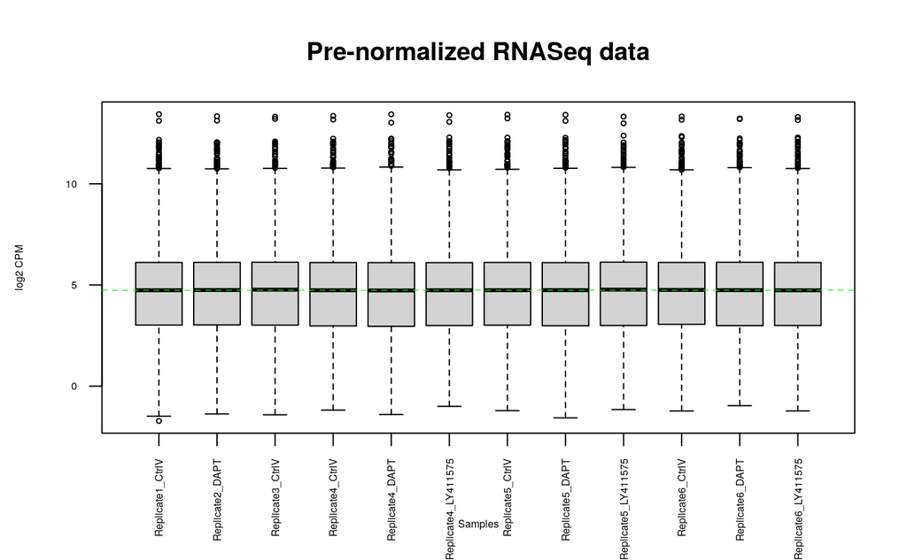

```r
# boxplot for pre-normalized dataset
# we do add a pseudocount of 0.25 to ensure negative log values do not explode
data2plot <- log2(cpm(filtered_tbl)+0.25)

boxplot(data2plot,xlab = "Samples", ylab = "log2 CPM",
 las = 2, cex = 0.5, cex.lab = 0.5,
 cex.axis = 0.5, main = "Pre-normalized RNASeq data")

#draw the median on each box plot
abline(h = median(apply(data2plot, 2, median)),
 col = "green", lwd = 0.6, lty = "dashed")
```

Interestingly, despite having downloaded the raw RNA-seq data, the overall distributions between the samples look almost identical, with medians and quartiles at the same values. We will nevertheless still apply a normalization to see what it looks like. This is confirmed by the density plot, as shown below:

```r
# note that this plotting code is based on Lecture 5 notes

counts_density <- apply(data2plot, 2, density)

# calculate the limits across all the samples
xlim <- 0
ylim <- 0
for (i in 1:length(counts_density)) {
  xlim <- range(c(xlim, counts_density[[i]]$x))
  ylim <- range(c(ylim, counts_density[[i]]$y))
}

cols <- rainbow(length(counts_density))
ltys <- rep(1, length(counts_density))

# plot the first density plot to initialize the plot
plot(counts_density[[1]], xlim=xlim, ylim=ylim, type="n",
     ylab="Smoothing density of log2-CPM",
     main="", cex.lab = 0.85)

# plot each line
for (i in 1:length(counts_density))
  lines(counts_density[[i]], col=cols[i], lty=ltys[i])
```

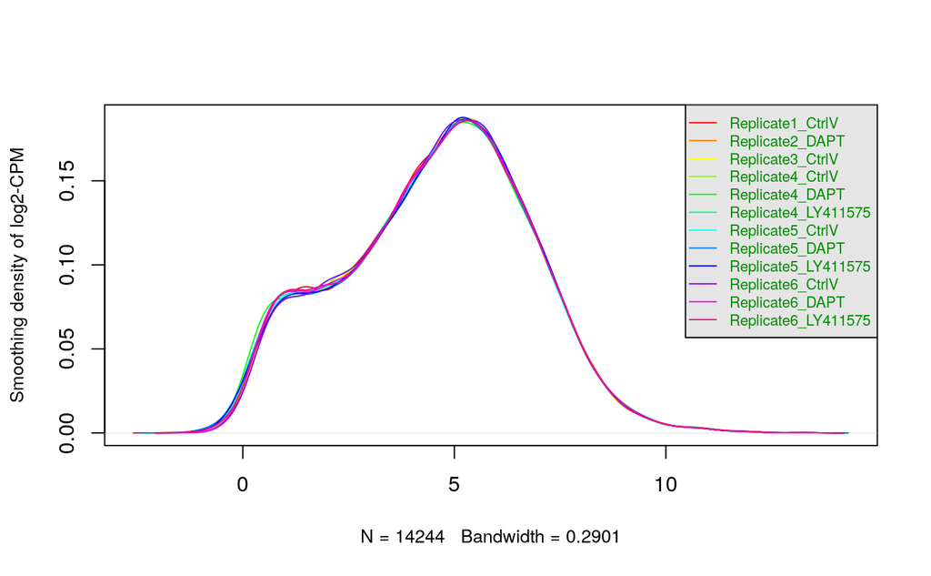

```r
# create legend
legend("topright", colnames(data2plot),
       col=cols, lty=ltys, cex=0.7,
       border ="blue", text.col = "green4",
       merge = TRUE, bg = "gray90")
```

### Normalization using TMM

```r
filtered_data_matrix <- as.matrix(filtered_tbl)

# groups <- colnames(filtered_tbl)
groups <- samples_type[, "treatment"]
# d = DGEList(counts=filtered_data_matrix, group=groups)
d = DGEList(counts=filtered_tbl, group=groups)
# normalization
d = calcNormFactors(d)
normalized_counts <- cpm(d)
nrow(normalized_counts)
```

```
[1] 14244
```

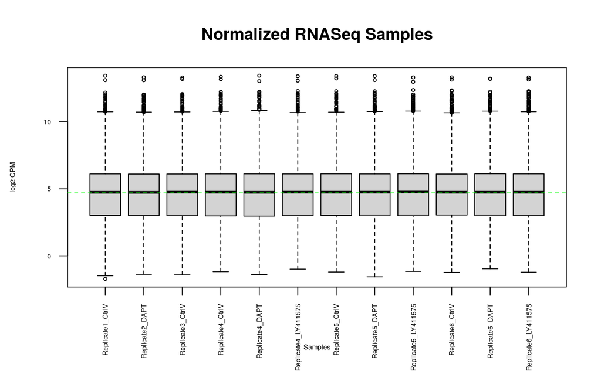

```r
# we do add a pseudocount of 0.25 to ensure negative log values do not explode
data2plot_after <- log2(normalized_counts + 0.25)
boxplot(data2plot_after, xlab = "Samples", ylab = "log2 CPM",
 las = 2, cex = 0.5, cex.lab = 0.5,
 cex.axis = 0.5, main = "Normalized RNASeq Samples")
#draw the median on each box plot
abline(h = median(apply(data2plot_after, 2, median)),
 col = "green", lwd = 0.6, lty = "dashed")
```

```r
# note that this plotting code is based on Lecture 5 notes

counts_density <- apply(data2plot_after, 2, density)

# Calculate the limits across all the samples
xlim <- 0
ylim <- 0
for (i in 1:length(counts_density)) {
  xlim <- range(c(xlim, counts_density[[i]]$x))
  ylim <- range(c(ylim, counts_density[[i]]$y))
}

cols <- rainbow(length(counts_density))
ltys <- rep(1, length(counts_density))

# Plot the first density plot to initialize the plot
plot(counts_density[[1]], xlim=xlim, ylim=ylim, type="n",
     ylab="Smoothing density of log2-CPM", main="", cex.lab = 0.85)

# Plot each line
for (i in 1:length(counts_density))
  lines(counts_density[[i]], col=cols[i], lty=ltys[i])
```

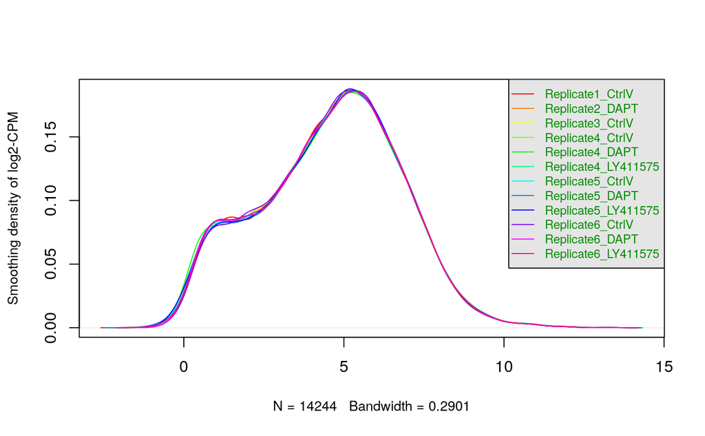

```r
# Create legend
legend("topright", colnames(data2plot),
       col=cols, lty=ltys, cex=0.75,
       border ="blue", text.col = "green4",
       merge = TRUE, bg = "gray90")
```

We can see that these results are essentially identical to the plot we made earlier. In fact, the normalization factors are all very close to 1, which probably means that the data had already been normalized. Note that the dataset used in this analysis is supposed to be the raw RNA-seq counts. Thus, the original data submitted to GEO had likely been pre-normalized, and NCBI simply performed the processing work to map the data to gene-level counts.

## Step 4: Initial Analysis and Discussion

In this step, we can perform further analyses to see how the data is distributed, as well as how seeing how samples differ across treatments.

### MDS Plotting

We can visualize the sample separation using a multidimenstional scaling plot post normalization. We can see from the MDS plot below that there does seem to be some separation between the control samples and the ones with the γ-secretase inhibitors.

```r
plotMDS(d, labels=NULL,pch=1,
  col = c("darkgreen","blue", "red")[factor(samples_type[, "treatment"])]
)
par(xpd = T)
```

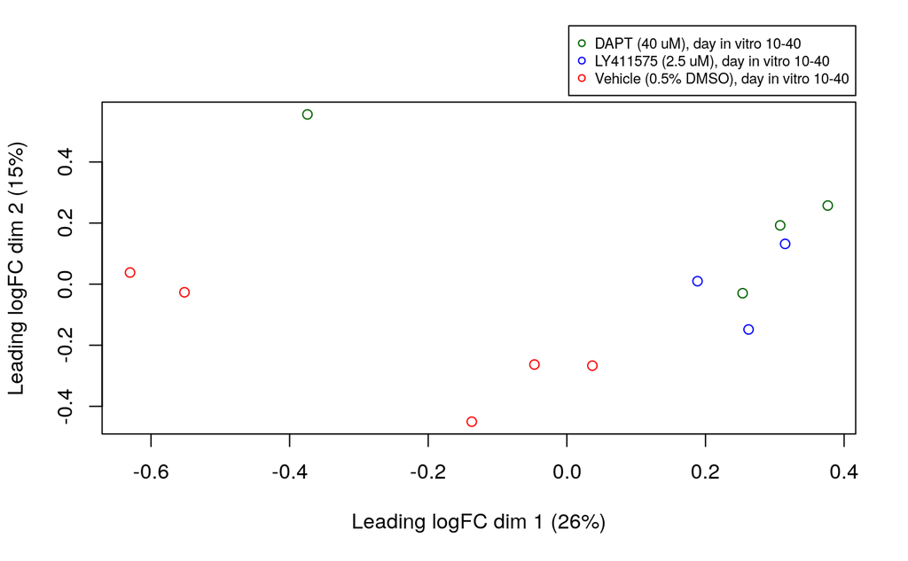

```r
legend("topright",
legend=levels(factor(samples_type[, "treatment"] )),
pch=c(1), col= c("darkgreen","blue", "red"),
cex = 0.7, inset=c(0,-0.23))
```

### Dispersion Plotting

The dispersion analysis is performed below. The plot seems to indicate that the dispersion is roughly constant across the genes. This may suggest consistent technical variability.

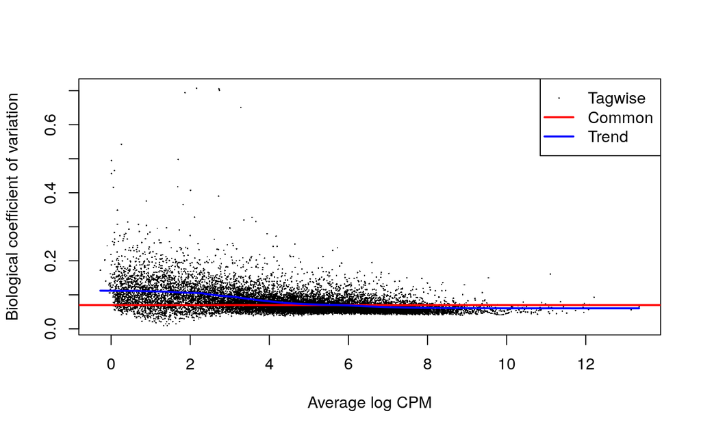

```r
model_design <- model.matrix(~samples_type[, "treatment"])
d <- estimateDisp(d, model_design)
plotBCV(d, col.tagwise = "black", col.common = "red", )
```

### Mean Variance Plotting

As shown below, it seems like the data follows a negative binomial distribution, with the points following relatively closely the blue line.

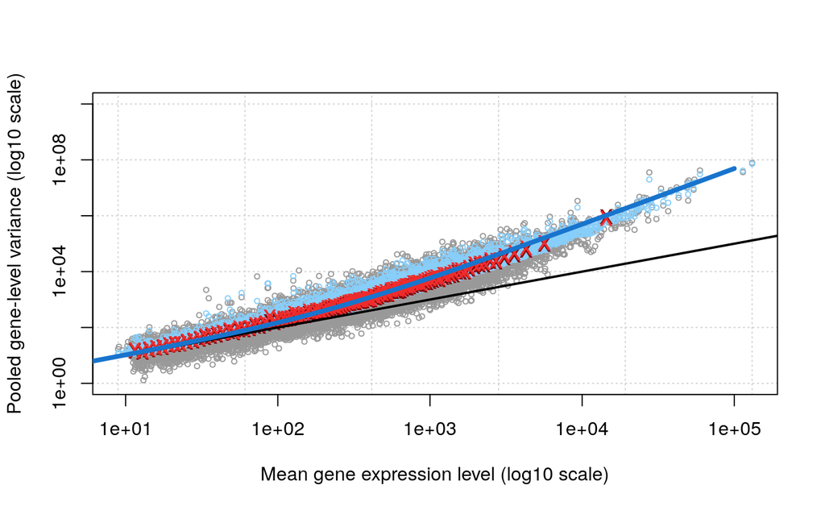

```r
plotMeanVar(d, show.raw.vars = TRUE, show.tagwise.vars = TRUE, NBline = TRUE,
            show.ave.raw.vars = TRUE, show.binned.common.disp.vars = TRUE,
            ylim = c(1,1e10))
```

### Writing Out the Data

```r
write.table(normalized_counts,
            file.path(
              getwd(),
              paste(dataset_geo_id,
                    "normalized_filtered_RSEM_counts.tsv",sep="_")
              ),
            quote = FALSE,sep="\t",row.names = TRUE)
```

### Questions and Answers

**Why is the dataset of interest to you?**  
Alzheimer’s disease (AD); it is the most common cause of dementia but there haven’t been any successful therapeutic interventions for this issue. More recently, there have been interesting observations regarding the relationship between dysfunction in lipid metabolism and neuroinflammation in AD. This dataset and its associate paper aims to elucidate this relationship by investigating the direct causal relationship between γ-secretase, cholesterol, and synapses.

**Were there expression values that were not unique for specific genes?**  
This dataset was originally published at the transcript level using ensembl transcript IDs. As such, I used the the NCBI-generated RNA-seq count data, which had gene-level expression, mapped to unique Entrez Gene IDs. However, when mapping to HUGO symbols, there was an issue with `biomaRt` returning multiple HGNC IDs for a single Entrez Gene ID, resulting in duplicate genes that had to be removed.

**Were there expression values that couldn’t be mapped to HUGO symbols?**  
There were a few genes in the original dataset that likely had outdated Entrez Gene IDs, as `biomaRt` was unable to locate their HUGO symbol. There was also the aforementioned issue with `biomaRt` returning multiple HGNC IDs for a single Entrez Gene ID. Overall, after the conversion step from transcript to gene-level expression, 1896 genes were omitted from the dataset.

**How did you handle replicates?**  
The dataset contained six biological replicates, each with three treatments. However, the data NCBI-generated RNA-seq count data only has twelve total samples, with Replicates 1-3 each missing two conditions. Nevertheless, because the samples did not seem to be highly paired between replicates, the analysis was performed on the 12 samples. Thus, the final output data table has 12 columns. Note that when removing genes with low sample counts, I removed entire rows to keep the data consistent.

## References

Davis, S. and Meltzer, P. S. GEOquery: a bridge between the Gene Expression Omnibus (GEO) and BioConductor. Bioinformatics, 2007, 14, 1846-1847

Essayan-Perez, Sofia, and Thomas C Südhof. “Neuronal γ-Secretase Regulates Lipid Metabolism, Linking Cholesterol to Synaptic Dysfunction in Alzheimer’s Disease.” Neuron, vol. 111, no. 20, 1 Oct. 2023, pp. 3176-3194.e7, https://doi.org/10.1016/j.neuron.2023.07.005.

Robinson MD, McCarthy DJ and Smyth GK (2010). edgeR: a Bioconductor package for differential expression analysis of digital gene expression data. Bioinformatics 26, 139-140

Mapping identifiers for the integration of genomic datasets with the R/Bioconductor package biomaRt. Steffen Durinck, Paul T. Spellman, Ewan Birney and Wolfgang Huber, Nature Protocols 4, 1184-1191 (2009).

Martin, Fergal J., et al. “Ensembl 2023.” Nucleic Acids Research, vol. 51, no. D1, 6 Jan. 2023, pp. D933–D941, pubmed.ncbi.nlm.nih.gov/36318249/, https://doi.org/10.1093/nar/gkac958.

Wickham H, Henry L (2023). *purrr: Functional Programming Tools*. R package version 1.0.2, https://github.com/tidyverse/purrr, https://purrr.tidyverse.org/.

Wickham H, François R, Henry L, Müller K, Vaughan D (2023). *dplyr: A Grammar of Data Manipulation*. R package version 1.1.4, https://CRAN.R-project.org/package=dplyr.

Yihui Xie (2015) Dynamic Documents with R and knitr. 2nd edition. Chapman and Hall/CRC. ISBN 978-1498716963